# Analyzing the Data to Ensure Reproducibility

What to hand off, how to keep track of it, and how to let someone rerun it

Naim Rashid

Department of Biostatistics · Lineberger Comprehensive Cancer Center · UNC

T32 Rigor and Reproducibility seminar · November 2, 2026

Slides, checklist and templates at github.com/naimurashid/rigor-reproducibility-resources

[figure not shown]

In 2009 Duke paused its cancer trials after outside statisticians found that a column of sample labels in a spreadsheet had shifted by one row. Duke’s review reported that the errors

“… did not affect the findings.”

Duke, as reported in 2010<sup>1</sup>

The trials restarted.

Most of reproducibility is what you hand off,

the raw data, a clean table, a codebook, and the code that connects them,

and getting that right pays you back when you write the paper.

## Overview

What goes wrong

Duke, a cancer biology replication project, and Excel.

What you hand off

Four things, to the analyst and to yourself.

How you make the analysis rerunnable

Four ways, easiest first.

What changes when an AI writes the code

Is this still happening?

## A signature that promised to pick the chemotherapy

In 2006 a Duke group reported gene expression signatures, built from cell lines, said to predict which chemotherapy a patient’s tumor would respond to<sup>6</sup>.

From 2007, Duke clinical trials assigned patients to chemotherapy by the signatures.

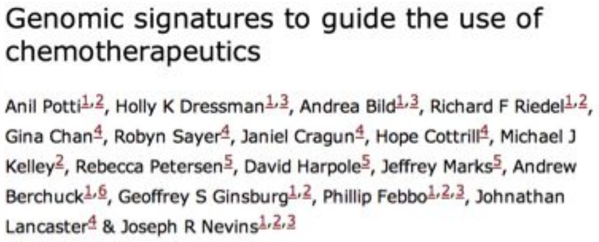

Nature Medicine, November 2006

## Two statisticians tried to rebuild it from the public data

Keith Baggerly and Kevin Coombes at MD Anderson tried to reproduce the signatures from the posted data, and could not<sup>7</sup>.

The errors they found were simple, and they wrote that the trials “may be putting patients at risk”.

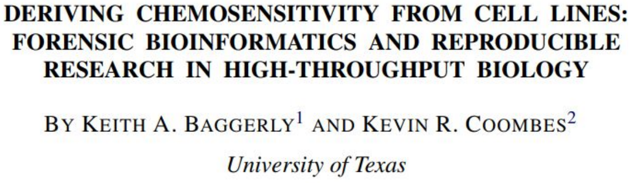

Annals of Applied Statistics, 2009

## What happened at Duke, 2006 to 2011

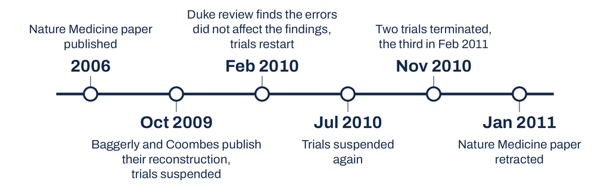

Patients were assigned to treatment using results nobody could rebuild.

## The first problems were bookkeeping errors

Sample labels off by one row

Sensitive and resistant swapped

Samples duplicated

“Poor documentation can shift from an inconvenience to an active danger when it obscures not just methods but errors.”

Baggerly and Coombes, 2009<sup>7</sup>

## Hope they don’t ask for the original data

“I can just hope they don’t ask for original data”

A coauthor of the 2006 paper, in an internal Duke email from 2008, as reported in The Cancer Letter, 2015<sup>4</sup>

Someone will ask.

## Cancer biology tried to replicate itself

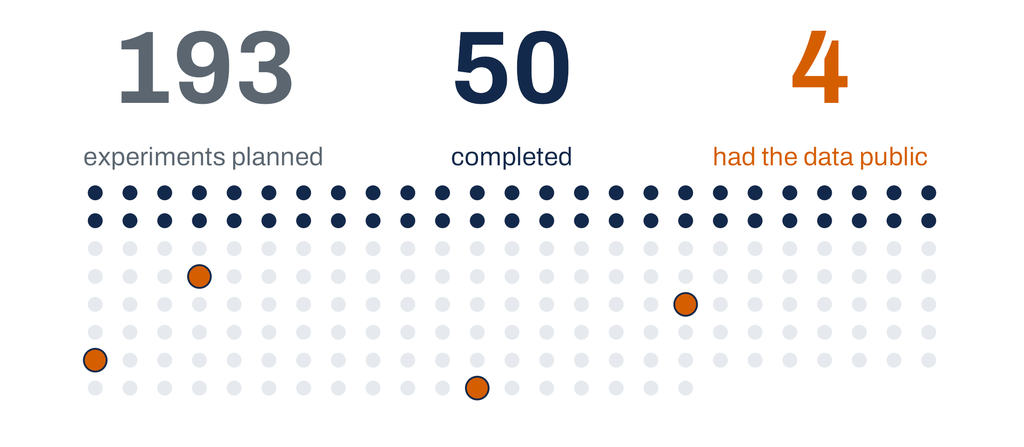

Reproducibility Project: Cancer Biology, 2021<sup>8</sup>

## The results that could be replicated got smaller

85%

smaller median effect than the original, for positive original effects

40%

of positive effects replicated on three or more of five criteria

And for 68 percent of the planned experiments, the original data could not be obtained at all<sup>8</sup>.

## Excel is still changing gene names

SEPT2 becomes 2-Sep.

**31%** of papers with supplementary Excel gene lists, 2014 to 2021, had errors, with no decline after a 2016 warning<sup>11</sup>.

The fix is to import gene columns as text, or turn off automatic date conversion in Excel.

POLL Have you ever opened a gene list in Excel?

## Who it costs

**Patients**  
The Duke trials assigned treatment using signatures that could not be rebuilt.

**Coauthors**  
In 2024 Dana-Farber asked for six retractions and 32 corrections after reports of duplicated images<sup>12</sup>.

**You**  
Original authors were asked for data from their own published papers, and often could not supply it<sup>8</sup>.

## What I am not saying

I am not asking you to become a programmer.

I am not telling you to stop using Excel.

I am not telling you to stop using AI.

What do you hand to the analyst, and to yourself next year?

## Four things, every time

**Raw data**  
exactly as the instrument produced it

**Tidy table**  
one row per observation

**Codebook**  
what each column means

**Recipe**  
the steps from raw to tidy

After Jeff Leek, “How to share data with a statistician”

The analyst might be a core, a labmate, or you in a year.

## The raw data stays raw

- The file as produced, by instrument, export or hand
- Kept in a read-only folder
- Nothing processed, summarized or deleted

For patient data, a dated read-only REDCap or registry export.

For sequencing data, keep the checksum (a short code computed from the file), which in practice changes whenever the file does.

## One row per observation, one column per variable

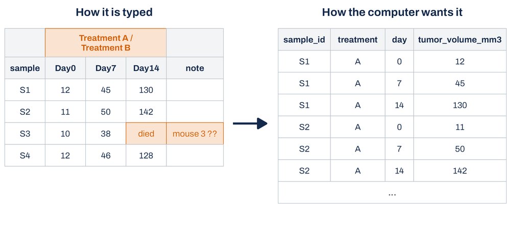

This layout is called tidy data, and most analysis software expects it<sup>14</sup>.

## What is wrong with this sheet?

EXERCISE Three minutes. Type answers in the chat.

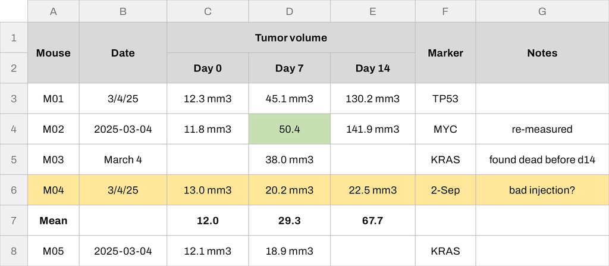

## What is wrong with this sheet?

ANSWERS Seven problems.

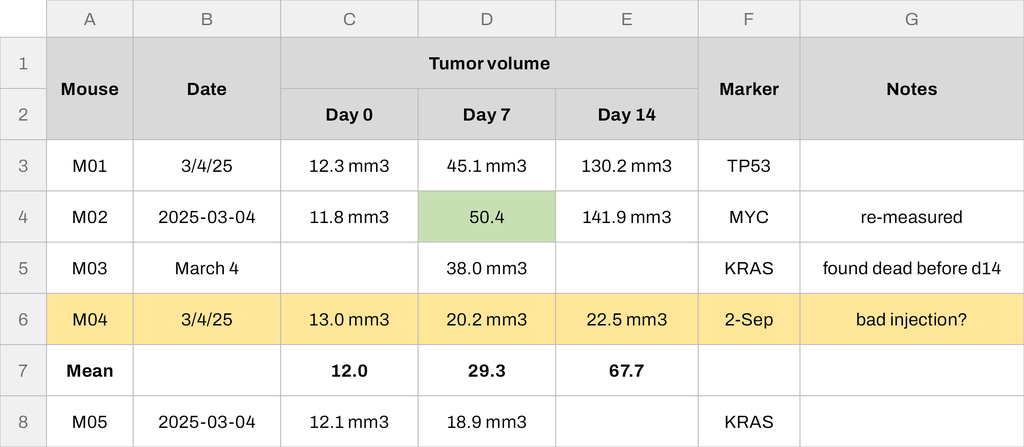

Two merged header rows · Color carries meaning · Units typed in cells · Blanks mean different things · Three date formats · SEPT2 became a date · A mean row inside the data

## Rules for the sheet you type into

- Be consistent
- One header row
- No color as data
- Document missing values consistently
- Dates as YYYY-MM-DD
- No calculations in the raw sheet
- Save a CSV copy

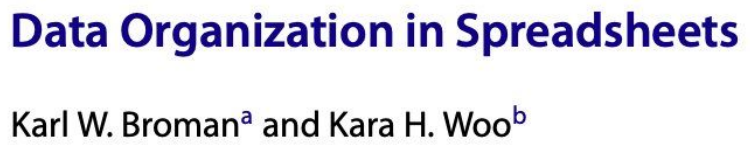

Broman and Woo, 2018<sup>15</sup>

## The codebook, the part most often skipped

| Variable | Description | Units | Allowed values | Missing |
| --- | --- | --- | --- | --- |
| tumor_volume | caliper volume | mm³ | 0 or more | NA, reason in volume_note |
| group | treatment arm |  | Control, Treated | none |

Also record batch, plate, run date.

Template in the resources repo.

## The recipe, from raw to tidy with nothing done by hand

```r
raw <- read.csv("raw/plate_2027-01-15.csv")
# Drop well B7, bubble noted in the lab notebook
tidy <- raw[raw$well != "B7", ]
write.csv(tidy, "data/tidy.csv", row.names = FALSE)
```

Every exclusion, recode and model choice goes in the script, with the N before and after each exclusion.

## Your DMS plan, mostly written already

| NIH data sharing (DMS) policy | January 2023 |
| --- | --- |
| Shorter plan | May 2026 |
| Progress in the RPPR | October 2026 |
| Data repository | GEO, SRA or GDC, then Zenodo or Dryad |
| Code | GitHub, archived with a DOI |
| Patient data | controlled access or none |

## Bring the analyst in at the design stage

Before samples are collected, agree on the design, the sample size and the structure of the data.

“Agree on data and metadata structure” and design experiments jointly<sup>19</sup>.

At UNC, ask the Lineberger Biostatistics Core or Bioinformatics Core.

How do you make the analysis itself rerunnable?

## Four ways to make an analysis rerunnable, from easiest to hardest

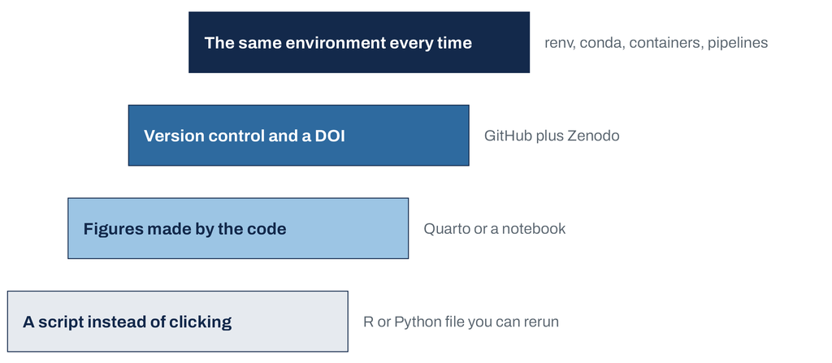

POLL Which of these do you do today?

## A script instead of clicking

Point-and-click tools such as Prism leave no record that reruns from the raw file.

A script in R, Python, SAS or Stata is that record.

**The test.** Delete the output, rerun the script, and get the same figure.

## The figures come out of the code

````markdown
---
format: html
---

```{r}
tidy <- read.csv("tidy-sheet.csv")
boxplot(tumor_volume ~ group, data = tidy)
```

Figure 1 shows tumor volume by group.
````

Quarto turns this file into a report<sup>20</sup>, as does a Jupyter notebook run from a clean start.

The sentence describes the figure, and any test of the difference is another block of code.

## Version control, and a DOI for the code

- Version control (Git, with GitHub) keeps labeled snapshots of your code you can return to.
- Zenodo gives each GitHub release a DOI, a permanent link that can be cited.
- Nature journals ask for a code availability statement.

Git is for code, not patient data.

## The same environment every time

**Lockfile**  
a list of exact package versions (renv, conda, pixi)

**Container**  
a sealed copy of the whole software setup (Docker, Apptainer on Longleaf)

**Pipeline**  
reruns only the steps whose inputs changed (targets, Nextflow, Snakemake)

At UNC, ask Research Computing or the Lineberger Bioinformatics Core.

## What this looks like in a real paper

Hillary Heiling’s 2024 Biometrics paper, from her dissertation work in the lab<sup>22</sup>

**Repository**  
github.com/hheiling/paper_glmmPen_FA

**README**  
how to install the package and rebuild the tables

```r
install.packages("glmmPen")
source("paper_glmmPen_FA/Replication/replication.R")
```

The README gives the commands that rebuild the paper’s tables from the saved results.

## The work moves to the start of the project

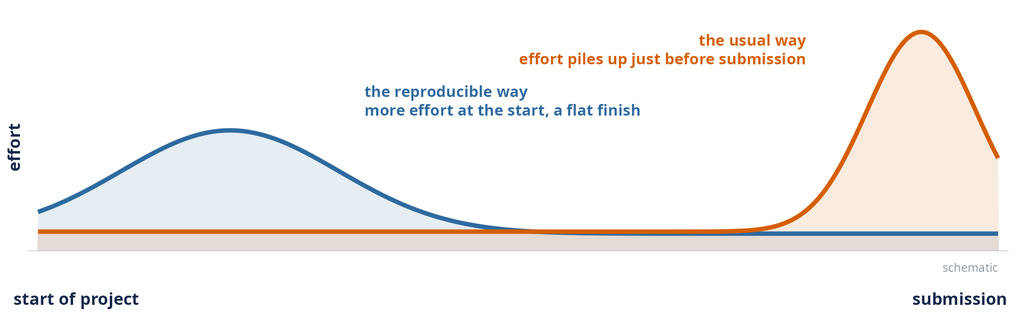

Effort moves from the week before submission to the first week of the project.

What changes when an AI writes the code?

## AI can do the execution, the responsibility stays with you

**What AI can help with**  
execution, options, critique, drafting

**What stays yours**  
what was chosen, why, and what the result means

POLL Have you used an AI assistant for analysis code in the last month?

## Same prompt, different answers

One task was run **480** times, ten per combination of six models, two prompt styles and four temperature (randomness) settings.

The analytical results varied considerably, even within one configuration<sup>24</sup>.

Rerunning the prompt gives different code, so save the code, not the prompt.

## It will invent a package name

5.2%

of packages named by commercial models did not exist

21.7%

of packages named by open-source models did not exist

Averages over 16 code models, lower bounds<sup>26</sup>

Check that a package exists, who maintains it and for how long. CRAN and Bioconductor review submissions (PyPI does not), but none guarantees safety.

## What the journals and NIH now require

| Nature, Science | no AI authors, and AI use disclosed in the paper<sup>27</sup> |
| --- | --- |
| NIH peer review | reviewers may not use generative AI, since June 2023<sup>28</sup> |
| NIH applications | applications substantially developed by AI are not treated as original, from September 2025<sup>29</sup> |

## How to use it and still be able to rerun your work

1. Keep the generated code with the paper, noting the model and version.
2. Run the saved code twice from a clean start and compare.
3. Read the code as you would a labmate’s draft.
4. Be able to explain the code with the AI tool closed.

## We cannot evaluate what we do not understand

As AI takes over more of the execution, the intuition and judgment we develop through rigorous training become more important, not less.

The more we rely on AI, the more essential it becomes to know when not to trust it.

## Reproducible research can still be wrong

Reproducible means the same data and code give the same result, replicable that a new experiment does<sup>30</sup>. Neither means correct.

A rerunnable analysis of a bad design is still wrong. Leek and Peng argue for training before the paper, not review after<sup>31</sup>.

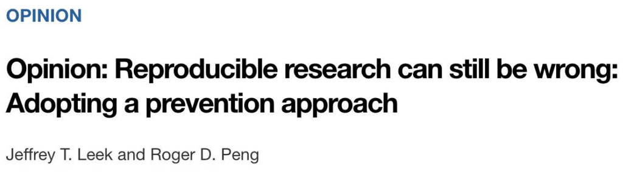

PNAS, 2015

NIH modules cover design, randomization, blinding, sample size.

## When to talk to a statistician

When you are not sure, turn to someone who has the training and expertise.

When you are not sure.

When you are too sure.

When the stakes are high.

Bring the four things, the raw data, the tidy table, the codebook and the recipe.

Most of reproducibility is what you hand off, the raw data, a clean table, a codebook, and the code that connects them, and getting that right pays you back when you write the paper.

## Resources

**From this talk**

- Handoff checklist
- Codebook template
- Messy and tidy example sheets

**To keep learning**

- The Turing Way
- The Carpentries
- NIH rigor training modules
- Lab handbook, data provenance and project consistency

[figure not shown]

**Resources repo**  
github.com/naimurashid/rigor-reproducibility-resources

Questions

naim@unc.edu · naimurashid.github.io

## References

1.

Stu Hutson. Data handling errors spur debate over clinical trial. Nature Medicine. 2010;16(6):618–8. doi:10.1038/nm0610-618a

2.

Institute of Medicine. Evolution of translational omics: Lessons learned and the path forward [Internet]. Washington, DC: The National Academies Press; 2012. Available from: https://doi.org/10.17226/13297 doi:10.17226/13297

3.

Anil Potti, Holly K Dressman, Andrea Bild, Richard F Riedel, Gina Chan, Robyn Sayer, Janiel Cragun, Hope Cottrill, Michael J Kelley, Rebecca Petersen, David Harpole, Jeffrey Marks, Andrew Berchuck, Geoffrey S Ginsburg, Phillip Febbo, Johnathan Lancaster, Joseph R Nevins. Retraction note: Genomic signatures to guide the use of chemotherapeutics. Nature Medicine. 2011 Jan;17(1):135. doi:10.1038/nm0111-135

4.

The Cancer Letter. Duke scientist: I hope NCI doesn’t get original data [Internet]. 2015. Available from: https://cancerletter.com/free/20150116_1/

5.

Office of Research Integrity. Findings of research misconduct (anil potti, m.d., duke university school of medicine) [Internet]. Federal Register 80(216):69230–69231, FR Doc. 2015-28437; 2015. Available from: https://www.govinfo.gov/content/pkg/FR-2015-11-09/pdf/2015-28437.pdf

6.

Anil Potti, Holly K Dressman, Andrea Bild, Richard F Riedel, Gina Chan, Robyn Sayer, Janiel Cragun, Hope Cottrill, Michael J Kelley, Rebecca Petersen, David Harpole, Jeffrey Marks, Andrew Berchuck, Geoffrey S Ginsburg, Phillip Febbo, Johnathan Lancaster, Joseph R Nevins. Genomic signatures to guide the use of chemotherapeutics. Nature Medicine. 2006 Oct;12(11):1294–300. doi:10.1038/nm1491

7.

Keith A. Baggerly, Kevin R. Coombes. Deriving chemosensitivity from cell lines: Forensic bioinformatics and reproducible research in high-throughput biology. The Annals of Applied Statistics. 2009 Dec;3(4):1309–34. doi:10.1214/09-aoas291

8.

Timothy M Errington, Alexandria Denis, Nicole Perfito, Elizabeth Iorns, Brian A Nosek. Challenges for assessing replicability in preclinical cancer biology. eLife. 2021 Dec;10. doi:10.7554/elife.67995

9.

Timothy M Errington, Maya Mathur, Courtney K Soderberg, Alexandria Denis, Nicole Perfito, Elizabeth Iorns, Brian A Nosek. Investigating the replicability of preclinical cancer biology. eLife. 2021 Dec;10. doi:10.7554/elife.71601

10.

Peter Rodgers, Andy Collings. What have we learned? eLife. 2021 Dec;10. doi:10.7554/elife.75830

11.

Mandhri Abeysooriya, Megan Soria, Mary Sravya Kasu, Mark Ziemann. Gene name errors: Lessons not learned. PLOS Computational Biology. 2021;17(7):e1008984. doi:10.1371/journal.pcbi.1008984

12.

NBC News. Prestigious cancer research institute has retracted 7 studies amid controversy over errors [Internet]. 2024. Available from: https://www.nbcnews.com/science/science-news/cancer-institute-dana-farber-retracts-studies-errors-rcna143922

13.

Sylvain Lesné, Ming Teng Koh, Linda Kotilinek, Rakez Kayed, Charles G. Glabe, Austin Yang, Michela Gallagher, Karen H. Ashe. Retraction note: A specific amyloid- protein assembly in the brain impairs memory. Nature. 2024;631(8019):240–0. doi:10.1038/s41586-024-07691-8

14.

Hadley Wickham. Tidy data. Journal of Statistical Software. 2014;59(10). doi:10.18637/jss.v059.i10

15.

Karl W. Broman, Kara H. Woo. Data organization in spreadsheets. The American Statistician. 2018 Jan;72(1):2–10. doi:10.1080/00031305.2017.1375989

16.

National Institutes of Health. Final NIH policy for data management and sharing [Internet]. NIH Guide for Grants and Contracts, NOT-OD-21-013; 2020. Available from: https://grants.nih.gov/grants/guide/notice-files/NOT-OD-21-013.html

17.

National Institutes of Health. Updated elements of an NIH data management and sharing plan [Internet]. NIH Guide for Grants and Contracts, NOT-OD-26-046; 2026. Available from: https://grants.nih.gov/grants/guide/notice-files/NOT-OD-26-046.html

18.

National Institutes of Health. Implementation update: NIH data management and sharing plan requirements [Internet]. NIH Guide for Grants and Contracts, NOT-OD-26-100; 2026. Available from: https://grants.nih.gov/grants/guide/notice-files/NOT-OD-26-100.html

19.

Mark D. Robinson, Peiying Cai, Martin Emons, Reto Gerber, Pierre-Luc Germain, Samuel Gunz, Siyuan Luo, Giulia Moro, Emanuel Sonder, Anthony Sonrel, Jiayi Wang, David Wissel, Izaskun Mallona. Ten simple rules for computational biologists collaborating with wet lab researchers. PLOS Computational Biology. 2024;20(6):e1012174. doi:10.1371/journal.pcbi.1012174

20.

Posit. Announcing Quarto, a new scientific and technical publishing system [Internet]. 2022. Available from: https://posit.co/blog/announcing-quarto-a-new-scientific-and-technical-publishing-system/

21.

Apptainer Project. Migrating from Singularity [Internet]. Apptainer Admin Guide 1.0; 2021. Available from: https://apptainer.org/docs/admin/1.0/singularity_migration.html

22.

Hillary M. Heiling, Naim U Rashid, Quefeng Li, Xianlu L Peng, Jen Jen Yeh, Joseph G Ibrahim. Efficient computation of high-dimensional penalized generalized linear mixed models by latent factor modeling of the random effects. Biometrics. 2024 Jan;80(1). doi:10.1093/biomtc/ujae016

23.

Hillary M. Heiling, Naim U. Rashid, Quefeng Li, Joseph G. Ibrahim. glmmPen: High dimensional penalized generalized linear mixed models. The R Journal. 2024 Apr;15(4):106–28. doi:10.32614/rj-2023-086

24.

Jiaxin Cui, Rohan Alexander. Same prompt, different outcomes: Evaluating the reproducibility of data analysis by LLMs [Internet]. 2026. Available from: https://arxiv.org/abs/2602.14349

25.

Sayash Kapoor, Arvind Narayanan. Leakage and the reproducibility crisis in machine-learning-based science. Patterns. 2023;4(9):100804. doi:10.1016/j.patter.2023.100804

26.

Joseph Spracklen, Raveen Wijewickrama, A H M Nazmus Sakib, Anindya Maiti, Bimal Viswanath, Murtuza Jadliwala. We have a package for you! A comprehensive analysis of package hallucinations by code generating LLMs [Internet]. 2024. Available from: https://arxiv.org/abs/2406.10279

27.

Nature. Tools such as ChatGPT threaten transparent science; here are our ground rules for their use. Nature. 2023 Jan;613(7945):612. doi:10.1038/d41586-023-00191-1

28.

National Institutes of Health. The use of generative artificial intelligence technologies is prohibited for the NIH peer review process [Internet]. NIH Guide for Grants and Contracts, NOT-OD-23-149; 2023. Available from: https://grants.nih.gov/grants/guide/notice-files/NOT-OD-23-149.html

29.

National Institutes of Health. Supporting fairness and originality in NIH research applications [Internet]. NIH Guide for Grants and Contracts, NOT-OD-25-132; 2025. Available from: https://grants.nih.gov/grants/guide/notice-files/NOT-OD-25-132.html

30.

Prasad Patil, Roger D. Peng, Jeffrey T. Leek. A statistical definition for reproducibility and replicability [Internet]. bioRxiv 066803; 2016. Available from: https://doi.org/10.1101/066803 doi:10.1101/066803

31.

Jeffrey T. Leek, Roger D. Peng. Reproducible research can still be wrong: Adopting a prevention approach. Proceedings of the National Academy of Sciences. 2015 Feb;112(6):1645–6. doi:10.1073/pnas.1421412111

32.

National Institutes of Health. Advanced notice of coming requirements for formal instruction in rigorous experimental design and transparency to enhance reproducibility: NIH and AHRQ institutional training grants and individual fellowships [Internet]. NIH Guide for Grants and Contracts, NOT-OD-16-034; 2015. Available from: https://grants.nih.gov/grants/guide/notice-files/NOT-OD-16-034.html

33.

Leonard P. Freedman, Iain M. Cockburn, Timothy S. Simcoe. The economics of reproducibility in preclinical research. PLOS Biology. 2015;13(6):e1002165. doi:10.1371/journal.pbio.1002165

34.

Geir Kjetil Sandve, Anton Nekrutenko, James Taylor, Eivind Hovig. Ten simple rules for reproducible computational research. PLoS Computational Biology. 2013 Oct;9(10):e1003285. doi:10.1371/journal.pcbi.1003285

35.

Greg Wilson, Jennifer Bryan, Karen Cranston, Justin Kitzes, Lex Nederbragt, Tracy K. Teal. Good enough practices in scientific computing. PLOS Computational Biology. 2017;13(6):e1005510. doi:10.1371/journal.pcbi.1005510

36.

Simon Schwab, Perrine Janiaud, Michael Dayan, Valentin Amrhein, Radoslaw Panczak, Patricia M. Palagi, Lars G. Hemkens, Meike Ramon, Nicolas Rothen, Stephen Senn, Eva Furrer, Leonhard Held. Ten simple rules for good research practice. PLOS Computational Biology. 2022;18(6):e1010139. doi:10.1371/journal.pcbi.1010139

37.

Mark D. Wilkinson, Michel Dumontier, IJsbrand Jan Aalbersberg, Gabrielle Appleton, Myles Axton, Arie Baak, Niklas Blomberg, Jan-Willem Boiten, Luiz Bonino da Silva Santos, Philip E. Bourne, Jildau Bouwman, Anthony J. Brookes, Tim Clark, Mercè Crosas, Ingrid Dillo, Olivier Dumon, Scott Edmunds, Chris T. Evelo, Richard Finkers, Alejandra Gonzalez-Beltran, Alasdair J. G. Gray, Paul Groth, Carole Goble, Jeffrey S. Grethe, Jaap Heringa, Peter A. C ’t Hoen, Rob Hooft, Tobias Kuhn, Ruben Kok, Joost Kok, Scott J. Lusher, Maryann E. Martone, Albert Mons, Abel L. Packer, Bengt Persson, Philippe Rocca-Serra, Marco Roos, Rene van Schaik, Susanna-Assunta Sansone, Erik Schultes, Thierry Sengstag, Ted Slater, George Strawn, Morris A. Swertz, Mark Thompson, Johan van der Lei, Erik van Mulligen, Jan Velterop, Andra Waagmeester, Peter Wittenburg, Katherine Wolstencroft, Jun Zhao, Barend Mons. The FAIR guiding principles for scientific data management and stewardship. Scientific Data. 2016 Mar;3(1). doi:10.1038/sdata.2016.18

38.

Monya Baker. 1,500 scientists lift the lid on reproducibility. Nature. 2016 May;533(7604):452–4. doi:10.1038/533452a

39.

Kelly D. Cobey, Sanam Ebrahimzadeh, Matthew J. Page, Robert T. Thibault, Phi-Yen Nguyen, Farah Abu-Dalfa, David Moher. Biomedical researchers’ perspectives on the reproducibility of research. PLOS Biology. 2024 Nov;22(11):e3002870. doi:10.1371/journal.pbio.3002870